# Przywiązanie do miejsca - raport

Szymon Talaga

13.12.2014

Raport przedstawia procedurę skalowania baterii pytań odnoszących się do przywiązania do miejsca. Najpierw sprawdzona zostanie rzetelność ogólnej skali przywiązania do miejsca, zaś potem parametry 3-wymiarowej skali zakładającej nastepujące podskale: miejsce zastane, miejsce odkryte, brak przywiązania. Dokładny opis obu skal można znaleźć w: Lewicka, 2012. Jako, że wszystkie skale zostały już opracowane przez Lewicką, to sprawdzona zostanie tylko rzetelność uzyskana w próbie - analiza struktury (analiza czynnikowa) zostanie pominęta i zamiast tego zostanie przyjęte, że struktura odkryta przez autorkę skali obowiązuje i w tym przypadku. Ma to na celu zapewnienie porównywalności wyników. Procedura skalowania oparta jest o klasyczną teorię testów, zatem najważniejszym kryterium będzie współczynnik zgodności wewnętrznej $\alpha$-Cronbacha.

Wczytanie niezbędnych pakietów i funckji oraz zbioru danych:

```r
library(psych)
library(GPArotation)
library(doBy)
library(lattice)

load("../MainData/MainData3.RData")
D.back = D
```

## Skala ogólna

Ograniczenie zbioru danych tylko do pytań ze skali ogólnej:

```r
D = D[,which(names(D)=="attgen1"):which(names(D)=="attgen9")]
```

Rzetelność:

```r
alpha(D)
```

```
##
## Reliability analysis
## Call: alpha(x = D)
##
##   raw_alpha std.alpha G6(smc) average_r S/N   ase mean   sd
##       0.89      0.89    0.89      0.47 7.8 0.022  3.6 0.84
##
##  lower alpha upper     95% confidence boundaries
## 0.84 0.89 0.93
##
##  Reliability if an item is dropped:
##          raw_alpha std.alpha G6(smc) average_r S/N alpha se
## attgen1       0.87      0.87    0.87      0.46 6.8    0.025
## attgen2-      0.88      0.88    0.88      0.47 7.2    0.024
## attgen3-      0.88      0.88    0.88      0.49 7.7    0.024
## attgen4       0.87      0.87    0.87      0.45 6.6    0.025
## attgen5       0.88      0.88    0.88      0.48 7.4    0.024
## attgen6       0.87      0.87    0.87      0.46 6.7    0.025
## attgen7       0.86      0.86    0.86      0.44 6.3    0.026
## attgen8       0.87      0.87    0.87      0.46 6.7    0.025
## attgen9       0.88      0.88    0.88      0.48 7.4    0.024
##
##  Item statistics
##            n    r r.cor r.drop mean   sd
## attgen1  231 0.75  0.72   0.68  3.6 1.23
## attgen2- 231 0.68  0.63   0.59  4.4 0.96
## attgen3- 231 0.62  0.56   0.51  3.7 1.23
## attgen4  231 0.79  0.77   0.72  3.4 1.38
## attgen5  231 0.66  0.59   0.56  3.0 1.21
## attgen6  231 0.76  0.73   0.69  3.6 1.13
## attgen7  231 0.84  0.83   0.79  3.5 1.23
## attgen8  231 0.76  0.73   0.68  3.7 1.07
## attgen9  231 0.66  0.60   0.55  3.9 0.97
##
## Non missing response frequency for each item
##            1    2    3    4    5 miss
## attgen1 0.06 0.15 0.21 0.28 0.31    0
## attgen2 0.61 0.22 0.12 0.04 0.02    0
## attgen3 0.36 0.26 0.21 0.12 0.06    0
## attgen4 0.13 0.16 0.20 0.22 0.30    0
## attgen5 0.13 0.23 0.26 0.28 0.11    0
## attgen6 0.05 0.10 0.30 0.29 0.25    0
## attgen7 0.07 0.13 0.24 0.28 0.27    0
## attgen8 0.05 0.09 0.26 0.39 0.23    0
## attgen9 0.03 0.06 0.17 0.47 0.27    0
```

Jak widać dwie pozycje mają odwrócone skale, co musi zostać poprawione.

```r
for(i in 2:3) D[,i] = recodeVar(D[,i], c(1,2,3,4,5), c(5,4,3,2,1))
alpha(D)
```

```
##
## Reliability analysis
## Call: alpha(x = D)
##
##   raw_alpha std.alpha G6(smc) average_r S/N   ase mean   sd
##       0.89      0.89    0.89      0.47 7.8 0.022  3.6 0.84
##
##  lower alpha upper     95% confidence boundaries
## 0.84 0.89 0.93
##
##  Reliability if an item is dropped:
##         raw_alpha std.alpha G6(smc) average_r S/N alpha se
## attgen1      0.87      0.87    0.87      0.46 6.8    0.025
## attgen2      0.88      0.88    0.88      0.47 7.2    0.024
## attgen3      0.88      0.88    0.88      0.49 7.7    0.024
## attgen4      0.87      0.87    0.87      0.45 6.6    0.025
## attgen5      0.88      0.88    0.88      0.48 7.4    0.024
## attgen6      0.87      0.87    0.87      0.46 6.7    0.025
## attgen7      0.86      0.86    0.86      0.44 6.3    0.026
## attgen8      0.87      0.87    0.87      0.46 6.7    0.025
## attgen9      0.88      0.88    0.88      0.48 7.4    0.024
##
##  Item statistics
##           n    r r.cor r.drop mean   sd
## attgen1 231 0.75  0.72   0.68  3.6 1.23
## attgen2 231 0.68  0.63   0.59  4.4 0.96
## attgen3 231 0.62  0.56   0.51  3.7 1.23
## attgen4 231 0.79  0.77   0.72  3.4 1.38
## attgen5 231 0.66  0.59   0.56  3.0 1.21
## attgen6 231 0.76  0.73   0.69  3.6 1.13
## attgen7 231 0.84  0.83   0.79  3.5 1.23
## attgen8 231 0.76  0.73   0.68  3.7 1.07
## attgen9 231 0.66  0.60   0.55  3.9 0.97
##
## Non missing response frequency for each item
##            1    2    3    4    5 miss
## attgen1 0.06 0.15 0.21 0.28 0.31    0
## attgen2 0.02 0.04 0.12 0.22 0.61    0
## attgen3 0.06 0.12 0.21 0.26 0.36    0
## attgen4 0.13 0.16 0.20 0.22 0.30    0
## attgen5 0.13 0.23 0.26 0.28 0.11    0
## attgen6 0.05 0.10 0.30 0.29 0.25    0
## attgen7 0.07 0.13 0.24 0.28 0.27    0
## attgen8 0.05 0.09 0.26 0.39 0.23    0
## attgen9 0.03 0.06 0.17 0.47 0.27    0
```

Teraz skale odpowiedzi są poprawne. Jak widać skala osiąga bardzo wysoką rzetelność: $\alpha =$ 0,89. Może być zatem użyta bez przeszkód w dalszych analizach.

Rozkład wyników skali:

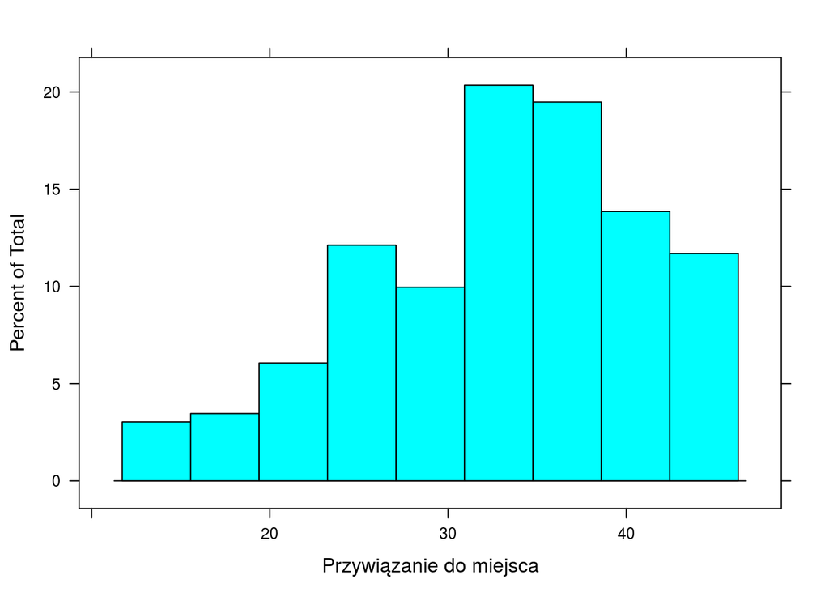

## Przywiązanie do miejsca - skala 3-wymiarowa

Teraz zostanie przedstawiona procedura skalowania skali 3-wymiarowej. Najpierw zbadana zostanie rzetelność wymiaru “miejsce zastane”.

**Miejsce zastane**

```r
D = D.back[,which(names(D.back)=="attmult1"):which(names(D.back)=="attmult18")]
place.given = names(D)[c(5,10,11,15,8,7)]
D.place.given = D[, place.given]
alpha(D.place.given)
```

```
##
## Reliability analysis
## Call: alpha(x = D.place.given)
##
##   raw_alpha std.alpha G6(smc) average_r S/N   ase mean   sd
##       0.59       0.6    0.64       0.2 1.5 0.055  2.2 0.71
##
##  lower alpha upper     95% confidence boundaries
## 0.48 0.59 0.7
##
##  Reliability if an item is dropped:
##            raw_alpha std.alpha G6(smc) average_r  S/N alpha se
## attmult5        0.47      0.47    0.48      0.15 0.87    0.068
## attmult10       0.48      0.48    0.50      0.16 0.94    0.068
## attmult11-      0.63      0.64    0.65      0.26 1.79    0.055
## attmult15       0.57      0.58    0.62      0.21 1.36    0.060
## attmult8        0.51      0.53    0.57      0.19 1.14    0.065
## attmult7        0.57      0.58    0.64      0.22 1.38    0.060
##
##  Item statistics
##              n    r r.cor r.drop mean   sd
## attmult5   231 0.72  0.72   0.50  2.2 1.14
## attmult10  231 0.69  0.67   0.47  2.2 1.23
## attmult11- 231 0.38  0.18   0.13  2.4 1.37
## attmult15  231 0.53  0.37   0.24  2.0 1.12
## attmult8   231 0.61  0.50   0.40  2.8 1.50
## attmult7   231 0.52  0.32   0.26  1.8 0.97
##
## Non missing response frequency for each item
##              1    2    3    4    5 miss
## attmult5  0.30 0.38 0.16 0.11 0.05    0
## attmult10 0.37 0.30 0.15 0.11 0.06    0
## attmult11 0.12 0.12 0.19 0.23 0.34    0
## attmult15 0.42 0.29 0.16 0.11 0.03    0
## attmult8  0.29 0.18 0.17 0.17 0.19    0
## attmult7  0.52 0.28 0.13 0.05 0.02    0
```

Pozycja attmult11 musi zostać odwrócona.

```r
D.place.given[,"attmult11"] = recodeVar(D[,"attmult11"], c(1,2,3,4,5), c(5,4,3,2,1))
alpha(D.place.given)
```

```
##
## Reliability analysis
## Call: alpha(x = D.place.given)
##
##   raw_alpha std.alpha G6(smc) average_r S/N   ase mean   sd
##       0.59       0.6    0.64       0.2 1.5 0.055  2.2 0.71
##
##  lower alpha upper     95% confidence boundaries
## 0.48 0.59 0.7
##
##  Reliability if an item is dropped:
##           raw_alpha std.alpha G6(smc) average_r  S/N alpha se
## attmult5       0.47      0.47    0.48      0.15 0.87    0.068
## attmult10      0.48      0.48    0.50      0.16 0.94    0.068
## attmult11      0.63      0.64    0.65      0.26 1.79    0.055
## attmult15      0.57      0.58    0.62      0.21 1.36    0.060
## attmult8       0.51      0.53    0.57      0.19 1.14    0.065
## attmult7       0.57      0.58    0.64      0.22 1.38    0.060
##
##  Item statistics
##             n    r r.cor r.drop mean   sd
## attmult5  231 0.72  0.72   0.50  2.2 1.14
## attmult10 231 0.69  0.67   0.47  2.2 1.23
## attmult11 231 0.38  0.18   0.13  2.4 1.37
## attmult15 231 0.53  0.37   0.24  2.0 1.12
## attmult8  231 0.61  0.50   0.40  2.8 1.50
## attmult7  231 0.52  0.32   0.26  1.8 0.97
##
## Non missing response frequency for each item
##              1    2    3    4    5 miss
## attmult5  0.30 0.38 0.16 0.11 0.05    0
## attmult10 0.37 0.30 0.15 0.11 0.06    0
## attmult11 0.34 0.23 0.19 0.12 0.12    0
## attmult15 0.42 0.29 0.16 0.11 0.03    0
## attmult8  0.29 0.18 0.17 0.17 0.19    0
## attmult7  0.52 0.28 0.13 0.05 0.02    0
```

Jak widać skala ma bardzo kiepską rzetelność. Zachodzi zatem ryzyko, że struktura czynnikowa skali w próbie może być inna. Najpierw jednak trzeba sprawdzić poziom rzetelności dwóch pozostałych skal.

**Miejsce odkryte**

Rzetelność tej skali sprawdzona w ten sam sposób, czyli w oparciu o współczynnik $\alpha$-Cronabacha:

```r
place.discovered = names(D)[c(16,6,3,9,14,4)]
D.place.discovered = D[, place.discovered]
alpha(D.place.discovered)
```

```
##
## Reliability analysis
## Call: alpha(x = D.place.discovered)
##
##   raw_alpha std.alpha G6(smc) average_r S/N   ase mean  sd
##       0.77      0.78    0.76      0.37 3.6 0.039  3.4 0.8
##
##  lower alpha upper     95% confidence boundaries
## 0.7 0.77 0.85
##
##  Reliability if an item is dropped:
##           raw_alpha std.alpha G6(smc) average_r S/N alpha se
## attmult16      0.73      0.74    0.71      0.36 2.9    0.047
## attmult6       0.71      0.72    0.68      0.34 2.6    0.049
## attmult3       0.78      0.78    0.75      0.42 3.6    0.043
## attmult9       0.73      0.74    0.70      0.36 2.8    0.048
## attmult14      0.73      0.74    0.70      0.36 2.8    0.047
## attmult4       0.75      0.76    0.73      0.39 3.2    0.045
##
##  Item statistics
##             n    r r.cor r.drop mean  sd
## attmult16 231 0.71  0.63   0.54  3.9 1.1
## attmult6  231 0.77  0.72   0.63  3.8 1.1
## attmult3  231 0.57  0.42   0.38  2.5 1.3
## attmult9  231 0.73  0.66   0.57  3.8 1.1
## attmult14 231 0.72  0.65   0.56  3.8 1.1
## attmult4  231 0.65  0.53   0.47  2.7 1.3
##
## Non missing response frequency for each item
##              1    2    3    4    5 miss
## attmult16 0.05 0.07 0.17 0.38 0.33    0
## attmult6  0.03 0.13 0.14 0.39 0.31    0
## attmult3  0.31 0.23 0.17 0.21 0.08    0
## attmult9  0.04 0.10 0.18 0.39 0.29    0
## attmult14 0.04 0.09 0.14 0.48 0.25    0
## attmult4  0.20 0.31 0.16 0.24 0.09    0
```

Jak widać ta skala osiągnęła satysfakcjonujący poziom rzetelności: $\alpha$ = 0,77. Sugeruje to zatem, że struktura czynnikowa narzędzia jest właściwa.

**Brak przywiązania**

Rzetelność:

```r
no.attachment = names(D)[c(1,17,13,12,18,2)]
D.no.attachment = D[, no.attachment]
alpha(D.no.attachment)
```

```
##
## Reliability analysis
## Call: alpha(x = D.no.attachment)
##
##   raw_alpha std.alpha G6(smc) average_r S/N  ase mean   sd
##       0.76      0.76    0.75      0.35 3.2 0.04  2.9 0.77
##
##  lower alpha upper     95% confidence boundaries
## 0.69 0.76 0.84
##
##  Reliability if an item is dropped:
##           raw_alpha std.alpha G6(smc) average_r S/N alpha se
## attmult1       0.76      0.76    0.74      0.38 3.1    0.044
## attmult17      0.74      0.73    0.71      0.36 2.8    0.046
## attmult13      0.74      0.74    0.73      0.36 2.8    0.046
## attmult12      0.69      0.69    0.66      0.30 2.2    0.051
## attmult18      0.71      0.71    0.68      0.33 2.5    0.049
## attmult2       0.73      0.73    0.70      0.35 2.7    0.047
##
##  Item statistics
##             n    r r.cor r.drop mean  sd
## attmult1  231 0.59  0.44   0.39  3.0 1.1
## attmult17 231 0.66  0.56   0.48  1.9 1.0
## attmult13 231 0.64  0.52   0.46  2.5 1.0
## attmult12 231 0.78  0.75   0.65  2.6 1.2
## attmult18 231 0.72  0.66   0.56  3.6 1.2
## attmult2  231 0.67  0.59   0.50  3.6 1.2
##
## Non missing response frequency for each item
##              1    2    3    4    5 miss
## attmult1  0.08 0.28 0.30 0.23 0.10    0
## attmult17 0.41 0.35 0.14 0.06 0.03    0
## attmult13 0.17 0.37 0.30 0.11 0.04    0
## attmult12 0.22 0.26 0.25 0.19 0.07    0
## attmult18 0.08 0.13 0.18 0.32 0.29    0
## attmult2  0.06 0.15 0.20 0.38 0.22    0
```

Ta skala również ma zadowoalającą rzetelność: $\alpha$ = 0,76. Oznacza to, że problemem w przypadku pierwszej skali nie jest nieodpowiednia względem próby struktura czynnikowa narzędzia, ale po prostu niedopasowanie niektórych pytań do jej specyfiki.

**Miejsce zastane - poprawa**

Kolejno sprawdzane było, które pozycje mogą zostać usunięte w celu poprawienia rzetelności całej skali. W ten sposób pozbyto się pozycji attmult11, attmult8, attmult7 i attmult15. Pozostały zatem jedynie pozycje attmult5 i attmult10. Rzut oka na treści pytań zdaje się potwierdzać słuszność tego podejścia - wszystkie odrzucone pozycje brzmią dosyć anachronicznie względem badanej tu próby, co sprawia, że udzielane na nie odpowiedzi mogą być w małym związku z rzeczywistym natężeniem przywiązania u osoby badanej, co w oczywisty sposób obniża rzetelność całej skali.

Rzetelność po usunięciu pozycji:

```
##
## Reliability analysis
## Call: alpha(x = D.place.given)
##
##   raw_alpha std.alpha G6(smc) average_r S/N   ase mean  sd
##        0.8       0.8    0.66      0.66   4 0.089  2.2 1.1
##
##  lower alpha upper     95% confidence boundaries
## 0.62 0.8 0.97
##
##  Reliability if an item is dropped:
##           raw_alpha std.alpha G6(smc) average_r S/N alpha se
## attmult5       0.66      0.66    0.44      0.66  NA       NA
## attmult10      0.66      0.66    0.44      0.66  NA       NA
##
##  Item statistics
##             n    r r.cor r.drop mean  sd
## attmult5  231 0.91  0.74   0.66  2.2 1.1
## attmult10 231 0.91  0.74   0.66  2.2 1.2
##
## Non missing response frequency for each item
##              1    2    3    4    5 miss
## attmult5  0.30 0.38 0.16 0.11 0.05    0
## attmult10 0.37 0.30 0.15 0.11 0.06    0
```

Jak widać po tych zabiegach podskala ‘miejsce zastane’ osiągnęła zdecydowania zadowalającą rzetelność: $\alpha$ = 0,80. Wartość współczynnika jest zbliżona do rzetelności dla pozostałych skal oraz wyników oryginalnie otrzymanych przez Lewicką (2012).

Rozkłady skal:

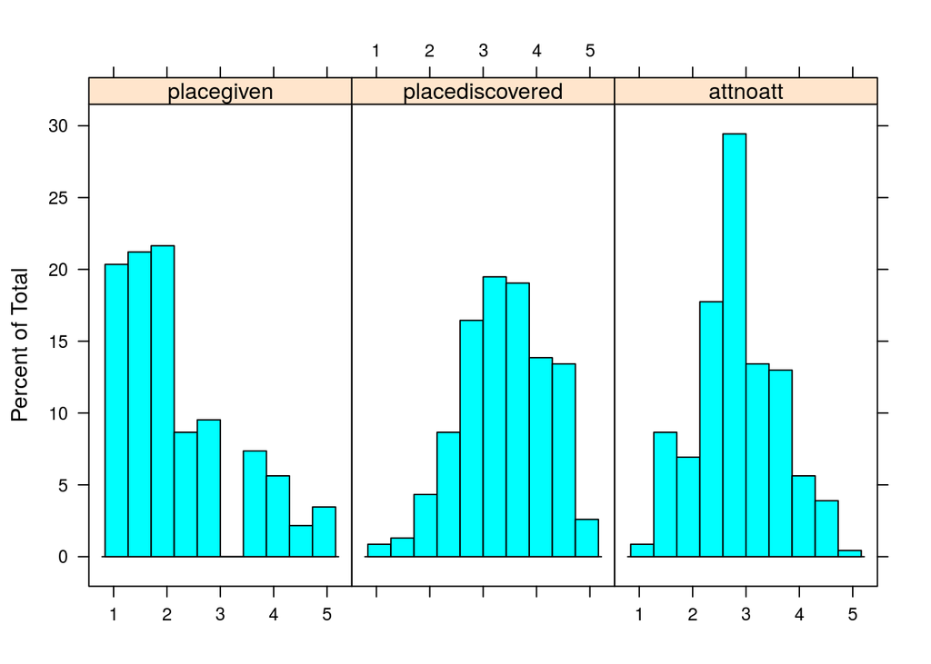

```r
D.back$attgen = attgen
D.back$placegiven = apply(D.place.given, 1, mean)
D.back$placediscovered = apply(D.place.discovered, 1, mean)
D.back$attnoatt = apply(D.no.attachment, 1, mean)
histogram(~placegiven+placediscovered+attnoatt, data=D.back, xlab="")
```

Oznacza to zatem, że wszystkie skale przywiązania są wystarczająca dobrej jakości oraz ich struktury czynnikowe są zgodne z oryginalnymi wynikami. Jedyną różnicą była konieczność ograniczenia zbioru pytań dla skali ‘miejsce zastane’ w celu dopasowania narzędzia do specyfiki badanej próby. Skale mogą być zatem użyte w dalszych analizach, przy czym najlepiej opierać się na skali ogólnej, która ma bardzo mały błąd pomiaru.

**Koniec raportu**